# Options.

Doynikov A.N.

21 ноября 2022 г

```r
knitr::opts_chunk$set(echo = TRUE)
Sys.getlocale()
```

```
## [1] "LC_COLLATE=English_United States.1252;LC_CTYPE=English_United States.1252;LC_MONETARY=English_United States.1252;LC_NUMERIC=C;LC_TIME=English_United States.1252"
```

```r
Sys.setlocale("LC_ALL", "russian_Russia.1251")
```

```
## [1] "LC_COLLATE=Russian_Russia.1251;LC_CTYPE=Russian_Russia.1251;LC_MONETARY=Russian_Russia.1251;LC_NUMERIC=C;LC_TIME=Russian_Russia.1251"
```

# Опцион. Определение

Существует два основных типа опциона. `Call option` дает владельцу право купить определенный товар к определенной заранее дате по фиксированной цене. Put option дает владельцу право продать определенный товар к определенной заранее дате по фиксированной цене. Эта фиксированная цена носит специальное название `exercise price` или `strike price`. Дата реализации контракта называется `expiration date`, или `exercise date` или `maturity`.

Американский опцион может быть реализован в произвольный день. Большинство торгуемых на рынке опционов именно американские. Однако, более просты для анализа европейские опционы, когда реализация опциона возможна только в момент `expiration date`. Основное отличие опционов от форвардов является то, что это именно право купить или продать, а не обязанность. В зависимости от состояния рынка обладатель опциона может и отказаться от реализации опциона. Поэтому, за это право инвесторы должны платить.

Подводим итог. Существуют четыре базовые позиции при торговле опционами:
$$1. long call option$$
$$2. long put option$$
$$3. short call option$$
$$4. short put option$$
Удобно характеризовать позицию в контракте как размер выплат инвестору в момент expiration Пусть $S(T)$ – цена акции в момент expiration, $X$ – страйк, тогда размер выплат для указанных выше типов опционов как функции от $S(t)$ будут иметь соответственно следующий вид:
$$1. max(S(T) -
X,0)$$
$$2. max(X - S(T),0)$$
$$3. min(X - S(T),0)$$
$$4. min(S(T) - X,0)$$

## Свойства цен опционов на акции

I.Основными факторами, влияющие на цены опционов на акции являются:

1. Текущая цена акции
2. Страйк
3. Время до окончания контракта
4. Волатильность цен акции
5. Безрисковая доходность
6. Дивиденты, ожидаемые в течении жизни опциона

### Предположения и обозначения.

Перед тем как получить соотношения между ценами опционов, сделаем необходимые предположения. Причем относительно вероятностного поведения пока предположений никаких делать не будем.

1. Транзакции проводятся бесплатно.
2. Все торговый доходы и потери имеют один и тот же рэйт.
3. Свободно возможен заем и наоборот кредитование под безрисковую доходность.
4. Участники рынка отслеживают и при первой возможности реализуют арбитражные операции.

В дальнейшем мы будем использовать следующие обозначения:

$S$ – Текущая цена акции

$X$ – страйк

$T$ – время окончания (expiration date)

$t$- текущее время

$S(T)$ - цена акции в момент окончания контракта

$r$ – безрисковая доходность

$С$ – цена Американского call опциона

$P$ – цена Американского put опциона

$с$ – цена Европейского call опциона

$p$ – цена Европейского put опциона

Пусть также $r>0$

### Верхняя и нижняя оценка стоимости опциона.

Верхняя граница.

Так как Американский и Европейский `call` опцион дает право купить акцию по фиксированной цене, то естественно
$$C<=S, с<=S$$

Если это не так, то арбитражеры моментально бы этим воспользовались, покупая акции и продавая ‘call’ опционы.

Аналогично Американский и Европейский put опцион дает право продать акцию по фиксированной цене, следовательно:
$$P<=X, p<=X$$
Для Европейского опциона последнее выражение можно усилить, а именно

`Теорема`
$$P<=Xexp(-r(T-t))$$

Пример. Пусть в какой-то момент времени S = 50 при X = 40. Тогда возникает желание реализовать опцион и получить доход. Однако это не всегда правильное решение. Предположим инвестору нужна еще и акция, которую он собирается держать больше чем 1 месяц.

В этом случае лучшей является стратегия держать опцион до конца.

Портфель E. один Американский `call’ и деньги $X exp(-r(T-t))$

Портфель F. Одна акция

В момент $T$ денег станет $X$, а в момент $\tau< T$ их будет $Xexp(-r(T-\tau))$. Если в момент времени $\tau$ реализовать опцион то портфель E будет стоить
$$S-X+Xexp(-r(T-τ))$$
И это естественно всегда меньше, чем $S$. Если же дождаться окончания опциона, то стоить портфель E будет $маx(S(T),X)$ , что уже не меньше чем цена портфеля $F$. Величина портфеля $F$ всегда равна $S(T)$ И всегда имеется шанс, что $S(T)<X$ . Поэтому обладание портфелем E всегда лучше, чем F.

Отсюда возникает следствие, что
$$С=с$$

### Put & Call Паритет

Портфель А. Один Eвропейский call и деньги в размере $X exp(-r(T-t))$

Портфель С. Один Eвропейский put и одна акция

В момент $Т$ оба портфеля стоят
$$маx(S(T),X).$$
Значит (в силу невозможности арбитража) они должны быть равны и в произвльный момент $t$. Итак
$$c+Xexp(-r(T-t))=p+S$$

## Модели поведения цен акций.

### Винеровском процесс.

Случайный процесс $\xi={\xi(t),t∈T}$

называется процессом с независимыми приращениями если для любых моментов времени

$$t_0<t_1<...<t_{n}$$

$$\xi(t_0),\xi(t_1)-\xi(t_0),...,\xi(t_{n})-\xi(t_{n-1})$$
независимы.

Процесс называется Гауссовским , если все его конечномерные распределения нормальные.

Гауссовский однородный процесс с независимымы приращениями называется винеровским (или процессом Броуновского движения)

Модели поведения цен акций обычно выражают в терминах так называемого Винеровского процесса. Винеровский процесс – частный случай Марковких процессов. Поведение случайной переменной, следующей Винеровскому процессу можно представить как изменение ее величины за бесконечно маленький интервал времени. Пусть $\Delta t$– небольшой интервал времени. Определим $\Delta z$ как изменение $z$ за время $\Delta t$.

Существуют два основных свойства, которым должно удовлетворять $\Delta z$ для процесса $z$ , который является Винеровским.

1. $\Delta z$ связано с $\Delta t$ соотношением

$$\Delta z=\epsilon\sqrt{\Delta
t}$$

где $\epsilon$- случайная величина со стандартным нормальным распределением.

2. Величины $\Delta z$ для двух различных интервалов времени стохастически независимы.

Из своства 1. Следует, что

$$E[\Delta z]=0$$
и
$$D[\Delta z]=\Delta t$$
Из свойств винеровского процесса и безграничной делимости нормального распределения следует, что оно может быть представлено как сумма изменений за $N$ небольших интервалов длины $\Delta t$, где $N=[T/\Delta t]$; Итак
$$z(T)-z(0) =
\sum_{i=1}^{N}\epsilon_{i}\sqrt{\Delta t}$$

Смоделируем винеровский процесс. Пусть$\Delta t= 1/365$ что сооветствует 1 календарному дню.

```r
    dt <- 1/365
    eps = rnorm(365,mean = 0,sd = 1)
    Z <- sum(eps*sqrt(dt))
    Z
```

```
## [1] 0.4697431
```

Это возможное изменение нашего винеровского процесса за год. Траектория процесса при этом будет такой.

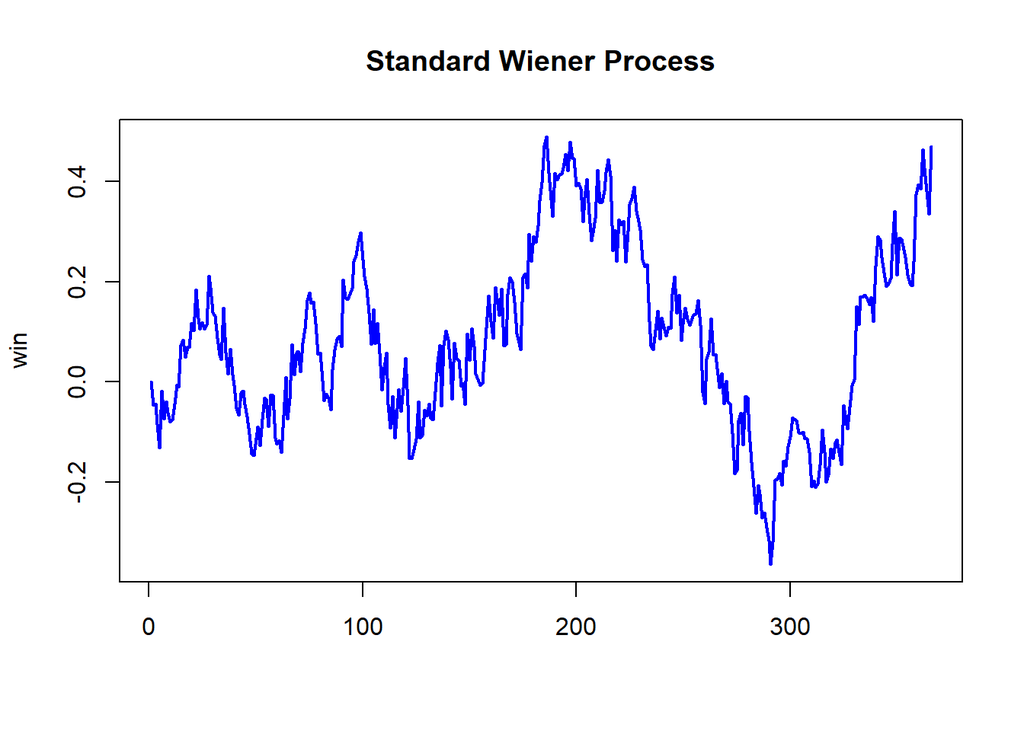

```r
  win <- diffinv(eps*sqrt(dt))
  matplot(win,main = "Standard Wiener Process",type = "l",lwd = 2,col = "blue")
```

### Обобщенный Винеровский процесс.

Обобщенным Винеровским процессом для переменной $x$ называется процесс определяемый как.
$$dx=adt+bdz$$
$a$ носит название коэффициента сноса, а $b$ – диффузии, на финансовых рынках $b$ принято называть волатильность. Второй слагаемое это $b$ раз Винеровский процесс. За промежуток времени $\Delta t$ изменение x составит:
$$\Delta x=a\Delta t+b\epsilon\sqrt(\Delta
t).$$

Так как $\epsilon$ - стандартная нормальная случайная величина то $x$ также имеет нормальное распределение со среднем
$$E[\Delta x]=a\Delta t$$
и дисперсией
$$D[\Delta x]=b^2\Delta t$$

Смоделируем обобщенный Винеровский процесс

```r
 a<- 0.03
 b <- 2.0
 genwin <- win*b
 adt <- seq(from = 0,to = 1,by = 1/364)
 x <- adt + win*b
```

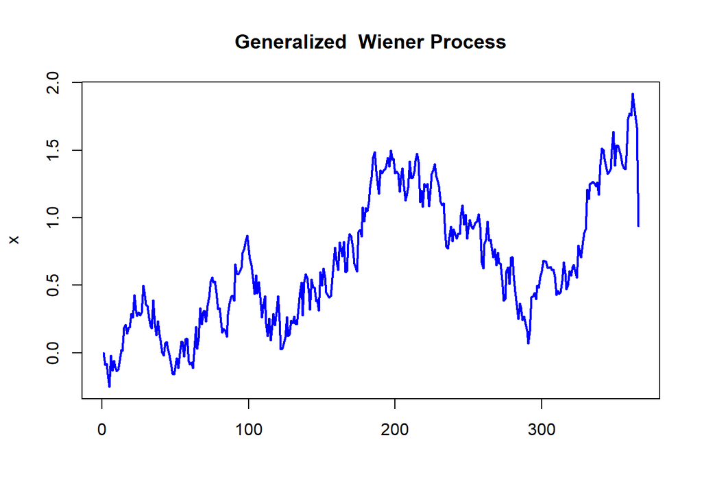

```r
 matplot(x,main = "Generalized  Wiener Process",type = "l",lwd = 2,col = "blue")
```

## Процесс Ито.

Смоделируем возможное поведение цены акции на год при волатильности $\sigma = 0.2$ И начальной цене акции $S=100$ и $\mu= 0.001$ согласно процесса Ито

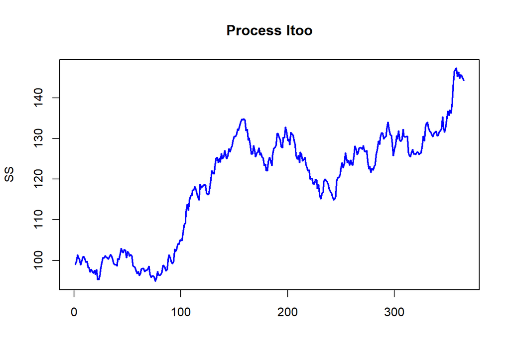

```r
set.seed (400)
S <- 100
sigma <- 0.2
mu <- 0.001
SS <- rep(0,365)
for (i in 1:365)
{
  dS <- S*rnorm(1,mu,sd = sqrt(sigma^2*dt))
  S <- S+dS
  SS[i] <- S
}
 matplot(SS,main = "Process Itoo",type = "l",lwd = 2,col = "blue")
```

### Оценка исторической волатильности

Пусть у нас имеется $n+1$ наблюдений $S(i)$ – цена акции в конце $i$-го интервала времени  - длина интервала времени в годах. Обозначим через
$$u(i) = ln(S(i)/S(i-1))$$

Так как $S(i) = S(i-1)exp(u(i))$, то $u(i)$ – можно рассматривать как непрерывно начисляемая доходность, но не привиденная к годовым, а единицу интервала между наблюдениями. В качестве оценки волатильности обычно используют следующую формулу
$$s =
\sqrt{\frac{1}{n-1}\sum_{i=1}^n(u(i)-\hat{u})^2}$$
Но ее еще необходимо привести к годовой волатильности.

Пусть $\tau$ длина интервала времени в годах. Тогда приведенная к годовым волатильность будет вычисляться так.
$$\sigma =
s/\sqrt{\tau}$$
В настоящее время стали также популярны другие выражения для оценки исторической волатильности с учетом цен открытия, закрытия, максимальной и минимальной цены. Посмотреть про них можно здесь https://portfolioslab.com/tools/yang-zhang http://tech.harbourfronts.com/garman-klass-yang-zhang-historical-volatility-calculation-volatility-analysis-python/

https://dynamiproject.files.wordpress.com/2016/01/measuring_historic_volatility.pdf

### Анализ Блэка-Шольца

В 1970 году Блэк, Шольц и Мертон сделали важнейший прорыв в решении дифференциальных уравнений, описывающих поведение цены производного финансового инструмента от цены базового актива. Их вклад позднее был оценен Нобелевской премией по экономике. Одним из основных математических инструментов, при этом явилась так называемая

#### Лемма Ито

Пусть случайный процесс $x$ следует процессу Ито
$$dx=a(x,t)dt+b(x,t)dz$$
и пусть $G(x,t)$- функция от $x$ и $t$, у которой существуют все необходимые частные производные. Тогда

$$dG=(a(∂G/∂x)+(∂G/dt)+(1/2)(∂²G/∂x²)b²)dt+(∂G/∂x)bdz$$
Таким образом процесс для $G(x,t)$ также Ито процесс со сносом
$$a(∂G/∂x)+(∂G/dt)+(1/2)(∂²G/∂x²)b²$$
и коэффициентом диффузии

$$(∂G/∂x)²b²$$
Пусть
$$(dS/S)=μdt+σdz$$
Тогда
$$dG = ((∂G/∂S)\mu
S+∂G/∂t+(1/2)(∂^2G/∂S^2)\sigma^2S^2)dt+ (∂G/∂S)\sigma S dz$$

### Дифференциальное уравнение Блэка-Шольца

Будем использовать следующие предположения при выводе и решении дифференциального уравнения Блэка-Шольца - Цена акции меняется согласно случайного процесса
$$dS/S=μdt+σdz$$
с постоянными $μ$ и $σ$. - Разрешена короткая продажа.

```
-   Транзакции бесплатны.

-   Все инстументы в нужном количестве делимы.

-   Нет выплат дивидентов во время жизни опциона

-   Невозможен безрисковой арбитраж

-   Торговля происходит при непрервном времени

-   Безрисовая доходность r -- постоянна для всех длительностей.
```

Позднее некоторый из сделанных предположений будут ослаблены. В частности $μ$ , $σ$ и $r$ могут быть известными функциями от времени. Итак, пусть $f$ – цена производного финансового инструмента на базовый актив $S$. И пусть $f$ – некоторая функция от $S$ и $t$. Тогда согласно леммы Ито
$$df=(((∂f)/(∂S))μS+((∂f)/(∂t))+0.5((∂²f)/(∂S²))σ²S²)dt+((∂f)/(∂S))σSdz$$
Соответственно дискретный версии

$$((ΔS)/S)=μΔt+σε√(Δt)$$

$$Δf=(((∂f)/(∂S))μS+((∂f)/(∂t))+0.5((∂²f)/(∂S²))σ²S²)Δt+((∂f)/(∂S))σSε√(Δt)$$
Согласно леммы Ито процесс $Δz=ε Δt$ тот же самый. Это приводит к тому, изменением портфеля акции и производного инструмента можно добиться так, что Винеровский процесс сократится. Таким портфелем будет:

Портвель А. 1 проданный производный инструмент

Портфель B. $∂f/∂S$ акций.

Держатель такого портфеля имеет короткую позицию по финансовой производной и длинную позицию по акциям. Определим $Π$ - как стоимость такого портфеля
$$Π=-f+((∂f)/(∂S))S$$
Дискретное изменение его стоимости составит
$$ΔΠ=-Δf+((∂f)/(∂S))ΔS$$
Подставляя вместо $Δf$ выражение из формулы Ито
$$ΔΠ=(-∂f/∂t-0.5∂²f/∂S²σ²S²Δt$$
Обратим внимание на то, что $Δz$-сокращается. Таким образом изменения портфеля можно сделать безрисковым. Из сделанных выше предположений об отсутствии арбитража имеем
$$ΔΠ=rΠΔt.$$
Подставляя это в формулу для $ΔΠ$,получим, переходя к пределу
$$∂f/∂t+rS∂f/∂S+0.5∂²f/∂S²σ²S²=rf$$
Полученное дифференициальное уравнение и есть уравнение Блэка-Шольца. Оно имеет много решений в соответствии различным производным инструментам на базовый актив $S$. Учет граничных условий позволяет найти частные решения. Например в случае Eвропейского call опциона эти граничные условия будут:

$f = max(S-X,0)$ при $t=T$

а для put опциона

$f = max(X-S,0)$ при $t=T$

### Применение к форвардному контракту

Рассмотрим форвардный контракт на бездивидентную акцию. Хорошо известна следующая формула для цены форвардного контракта
$$f = S-Ke^{-r(T-t)}$$
где $S$ - цена акции в момент времени $t$, $K$ - цена в момент заключения контракта, $T$ - время окончания контракта, а $f$ - стоимость вхождения или закрытия такого контракта в данный момент $t$.

Это призводный финансовый иструмент, следовательно его цена $f$ должна удовлетворять уравнению Блэка-Шольца. Проверим это, последовательно вычисляя необходимые частные производные.
$$\frac{∂f}{∂t}=-rKe^{-r(T-t)}$$
$$\frac{∂f}{∂S}=1$$
$$\frac{∂^2f}{∂t^2}=0$$
подставляя выражения для частных производных в уравнение Блэка-Шольца, получим
$$-rKE^{-r(T-t)}+rS=rf$$
. Но левая часть также равна
$$r(-KE^{-r(T-t)}+S)=rf$$
Итак, $rf= rf$, что и требовалось доказать.

### Риск-нейтральные вычисления

Риск-нейтральные вычисления без всякого сомнения являются наиболее важным средством для анализа финансовых производных. Это возникает из одного ключевого свойства дифференциального уравнения . Свойство это в том, что уравнение не включает в себя рисковую переменную. Переменные участвующие в уравнении это текущая цена акции, время, волатильность, безрисковая доходность. Все они не зависят от риска. Уравнение Блэка-Шольца не было бы независимым от риска если бы оно включало в себя ожидаемую доходность по акции $μ$ так как $μ$ может зависить от риска. Но к счастью $μ$ сократилось при выводе. Но если рисковые переменные не входят в уравнение, то они не влияют на его решение. Однако некоторое множество рисковых переменных может входить в $f$, однако можно сделать одно простое предположение,а имеено все инвесторы находятся в одинаковых условиях и все их инвестиции предполагаются риск-нейтральны. В риск нейтральном мире ожидаемый доход от всех инструментов есть безрисковая доходность $r$ и поэтому все текущие величины будущих выплат могут быть получены дисконтированием их ожидаемых значений (математического ожидания) на величину безрисковой доходности.

### Решение дифференициального уравнения Блэка-Шольца для Европейских опционов.

Математическое ожидание выплат по call опциону в момент окончания составит

$$E[max(S(T)-K,0]$$
Где символом E[..] обозначается математическое ожидание в риск нейтральном мире Из соображений риск нейтральности для цены c Европейского call опциона имеем

$$с=exp(-r(T-t))E[max(S(T)-K,0]$$

В риск нейтральном мире вероятностное распределение $ln(S(T))$ – нормальное

$$ln(S(T))∼φ(lnS+(r-((σ²)/2))(T-t),σ²(T-t))$$

Цена европейского put можно получить из call-put pariteta
$$p=Xexp(-r(T-t))N(-d2)-SN(-d1)$$

### Вычисление цены в R

Вычислим цены Европейских опционов на бездивидентную акцию на R

```r
library(fOptions)
S <- 100
T <- 0.25
sigma <- 0.2
r <- 0.01
b <- 0
X <- seq(from = 80, to= 120, by = 5)
TypeFlag <- "c"
call <- GBSOption(TypeFlag, S = S, X = X, Time = T, r = r, b = b, sigma = sigma)
summary(call)
```

```
##
## Title:
##  Black Scholes Option Valuation
##
## Call:
##  GBSOption(TypeFlag = TypeFlag, S = S, X = X, Time = T, r = r,
##      b = b, sigma = sigma)
##
## Parameters:
##           Value:
##  TypeFlag c
##  S        100
##  X1       80
##  X2       85
##  X3       90
##  X4       95
##  X5       100
##  X6       105
##  X7       110
##  X8       115
##  X9       120
##  Time     0.25
##  r        0.01
##  b        0
##  sigma    0.2
##
## Option Price:
##  19.98988 15.16373 10.68563 6.87087 3.977818 2.058871 0.9515615 0.393954 0.1469673
##
## Description:
##  Mon Nov 27 16:19:11 2023
```

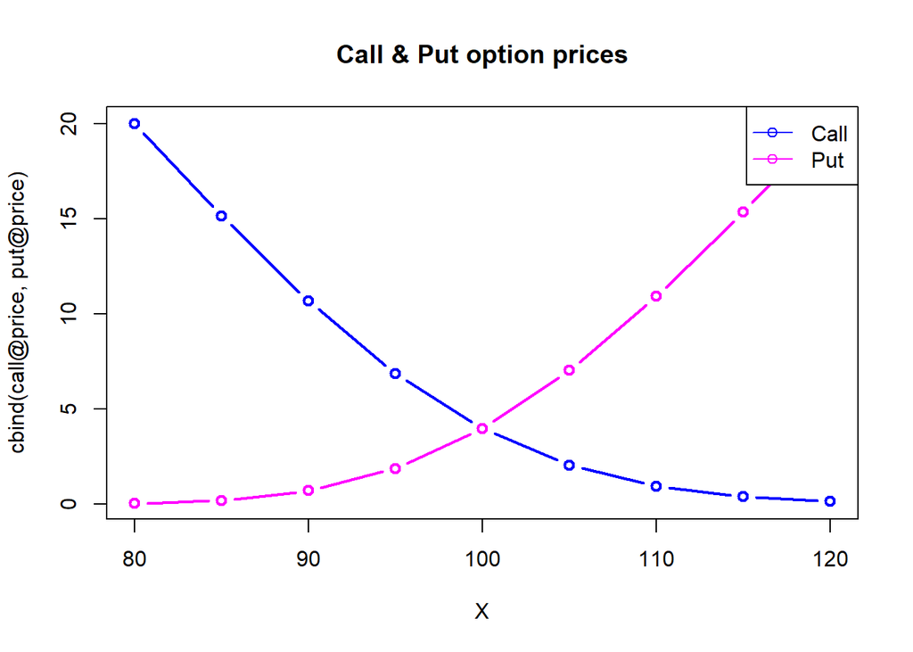

```r
TypeFlag <- "p"
put <- GBSOption(TypeFlag, S = S, X = X, Time = T, r = r, b = b, sigma = sigma)
matplot(X,cbind(call@price, put@price),type = "b",lty = 1,lwd = 2, pch = 21,main = "Call & Put option prices",col = c("blue","magenta"))
legend("topright",c("Call","Put"),col = c("blue","magenta"),lty= c(1,1),pch = c(21,21))
```

В следующем shiny реализовано моделирование возможной динамики процесса Ито и оценка стоимости европейского опциона по модели Блэка-Шольца и через моделирование его стоимости методом Монте-Карло http://shiny.ilykei.com/ANDoynikov/Options/Black_Scholes_model/

## Греки

Стратегии, основанные на продаже опционов более рискованны. И требуют страхования от катастрофических потерь. Многие модели страхования проданных опционов основаны на вычислении так называемых греческих букв или просто на жаргоне трейдеров “греков”.

### Дельта хеджирование

Определение. $\Delta$ опциона определяется как скорость изменения цены опциона относительно изменения цены базового актива Другими словами
$$\Delta
= ∂c/∂S$$
Например если $\Delta=0.$;6 то это означает, что если цена актива изменяется на небольшое значение, то цена опциона изменится на 60% от этой величины. Пусть цена акции 100$ и цена опциона 10$ Представим, что инвестор, который продал 20 опционов, т.е.опционов на покупку 2000 акций. Тогда позицию инвестора следует застраховать покупкой 0.6 * 2000 = 1200 акций. Доходы(потери) по опциону будут стремиться к компенсации потерями (доходами) от акций.

Итак стратегия  хеджирования

-1 производная

$\Delta$ единиц акций.

Для европейского call option короткая позиция в call требует длинной позиции акциях и, наоборот, длинная позиция с call требует короткой позиции в акциях в размере $N(d1)$

Для европейского put опциона.

$$\Delta= ∂p/∂S= N(d1) – 1 <
0$$

Для портфеля опционов на товар с ценой стоимостью $S$ $\Delta$ равен сумме $\Delta$ каждого опциона умноженного на количество опционов каждого типа

### Тета опциона.

Тета опциона или портфеля называется скорость изменения величины портфеля относительно времени, при условии, что все остальное не измнияется.

$$\Theta =∂\Pi/∂t$$
Для европейского call
$$\Theta =S(0)N’(d1)*/
(2sqrt(T)) – r X exp(-rT) N(d2)$$
Для европейского put
$$\Theta =-S(0)N’(d1)*/ (2sqrt(T)) – r X exp(-rT)
N(-d2)$$

Тета обычно отрицательна. Это вследствии того, по мере уменьшения времени цена опциона становится все меньше

### Гамма портфеля

Определение. Гамма портфеля называется вторая производная по цене актива.
$$\Gamma=∂^2\Pi/∂S^2$$
Если Гамма маленькая то дельта меняется медленно, что позволяет поддерживать дельта нейтральный портфель довольно спокойно. Гамма портфеля довольно чувствительна к изменению цены базового актива. Пусть $S$ – изменение цены акции за интервал времени $\Delta $t. И$\Delta\Pi$ изменение портфеля, тогда Для дельта нейтрального порфеля
$$\Delta \Pi =
\Delta t+0.5 \Gamma\Delta S^2$$

Гамма нейтральный портфеля обеспечивает защиту от больших движений в цене базового актива.

Гамма тета и дельта портфеля связаны между собой Подставляя вместо призводных в уранение Блэка-Шольца значения греческих букв получим
$$\Theta+rs\Delta+0.5\sigma^2S^22\Gamma=r\Pi$$

### Vega

Мы ранее предполагали, что волатильность постоянна, понятно, что это конечно не так Определение. Вега портфеля это скорость изменения величины портфеля относительно изменения волатильности

$$Vega = ∂\Pi/∂\sigma$$
 Если вега большая по абсолютной величине, то портфель очень чуствителен к изменениям волатильности

Позиция в опционе в размере –V/Vo, где Vo – Vega опциона у денег делает портфель vega нейтральным

Вычислим греков для нашего примера опциона

### Delta

```r
TypeFlag = 'c'
callDelta <- GBSGreeks(Selection = 'delta',TypeFlag=TypeFlag, S = S, X = X, Time = T, r = r, b = b, sigma = sigma)
callDelta
```

```
## [1] 0.98626993 0.95067182 0.86295764 0.71147884 0.51864065 0.32990303 0.18277838
## [8] 0.08866852 0.03800133
```

```r
TypeFlag = 'p'
putDelta <- GBSGreeks(Selection = 'delta',TypeFlag, S = S, X = X, Time = T, r = r, b = b, sigma = sigma)
callDelta
```

```
## [1] 0.98626993 0.95067182 0.86295764 0.71147884 0.51864065 0.32990303 0.18277838
## [8] 0.08866852 0.03800133
```

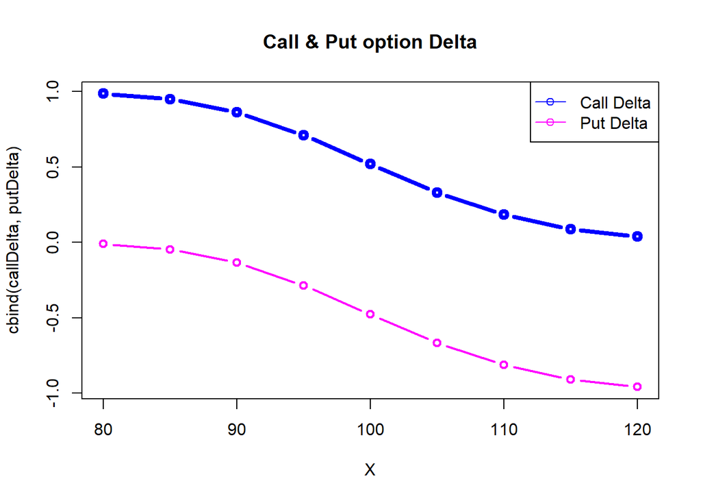

```r
matplot(X,cbind(callDelta, putDelta),type = "b",lty = 1,lwd = c(4,2), pch = 21,main = "Call & Put option Delta",col = c("blue","magenta"))
legend("topright",c("Call Delta","Put Delta"),col = c("blue","magenta"),lty= c(1,1),pch = c(21,21))
```

### Theta

```r
TypeFlag = 'c'
callTheta <- GBSGreeks(Selection = 'theta',TypeFlag=TypeFlag, S = S, X = X, Time = T, r = r, b = b, sigma = sigma)
callDelta
```

```
## [1] 0.98626993 0.95067182 0.86295764 0.71147884 0.51864065 0.32990303 0.18277838
## [8] 0.08866852 0.03800133
```

```r
TypeFlag = 'p'
putTheta <- GBSGreeks(Selection = 'theta',TypeFlag, S = S, X = X, Time = T, r = r, b = b, sigma = sigma)
callDelta
```

```
## [1] 0.98626993 0.95067182 0.86295764 0.71147884 0.51864065 0.32990303 0.18277838
## [8] 0.08866852 0.03800133
```

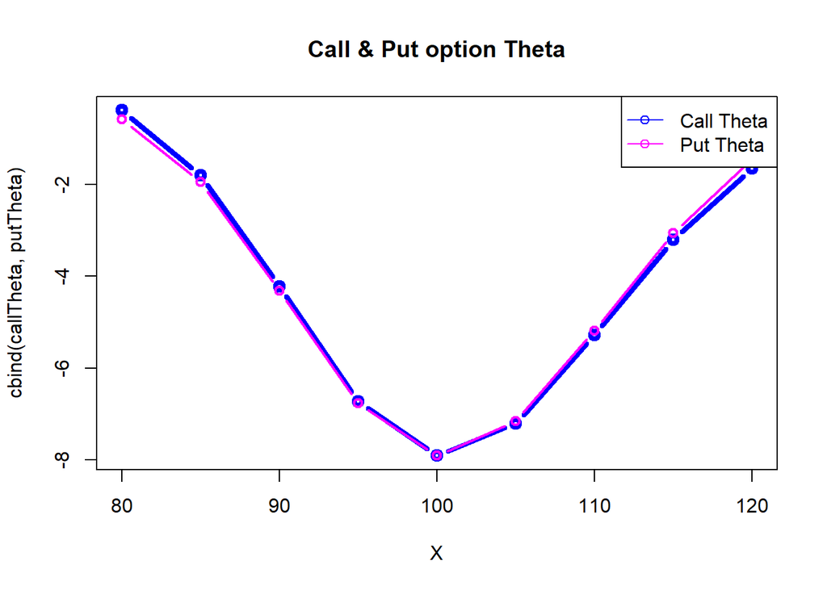

```r
matplot(X,cbind(callTheta, putTheta),type = "b",lty = 1,lwd = c(4,2), pch = 21,main = "Call & Put option Theta",col = c("blue","magenta"))
legend("topright",c("Call Theta","Put Theta"),col = c("blue","magenta"),lty= c(1,1),pch = c(21,21))
```

### Vega

```r
TypeFlag = 'c'
callVega <- GBSGreeks(Selection = 'vega',TypeFlag=TypeFlag, S = S, X = X, Time = T, r = r, b = b, sigma = sigma)
callDelta
```

```
## [1] 0.98626993 0.95067182 0.86295764 0.71147884 0.51864065 0.32990303 0.18277838
## [8] 0.08866852 0.03800133
```

```r
TypeFlag = 'p'
putVega <- GBSGreeks(Selection = 'vega',TypeFlag, S = S, X = X, Time = T, r = r, b = b, sigma = sigma)
callDelta
```

```
## [1] 0.98626993 0.95067182 0.86295764 0.71147884 0.51864065 0.32990303 0.18277838
## [8] 0.08866852 0.03800133
```

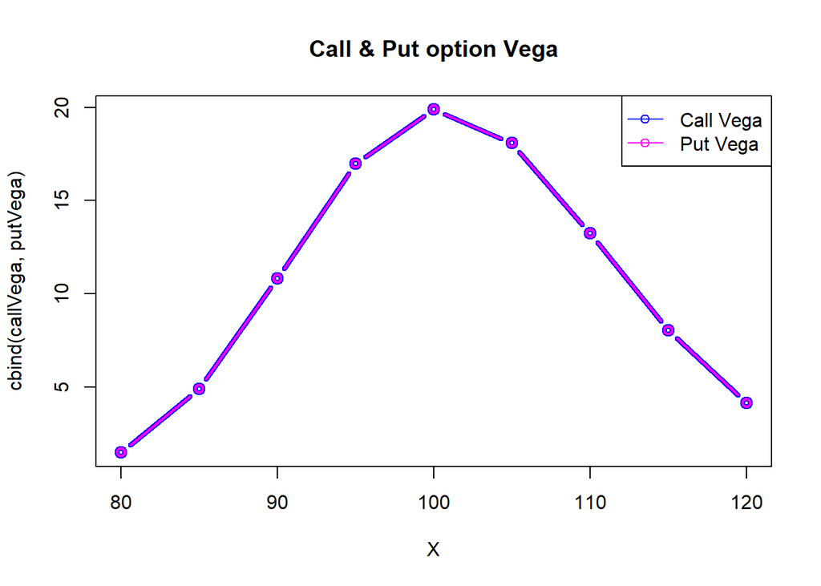

```r
matplot(X,cbind(callVega, putVega),type = "b",lty = 1,lwd = c(4,2), pch = 21,main = "Call & Put option Vega",col = c("blue","magenta"))
legend("topright",c("Call Vega","Put Vega"),col = c("blue","magenta"),lty= c(1,1),pch = c(21,21))
```

Гамму опциона получите самостоятельно

## Торги опционами в России

Торговля опционами в России осуществляется на бирже MOEX. Опционы торгуются американские, но считают многие по формулам для европейских опционов. Считаем типичную картинку торгов декабрьского опциона на декабрьский фьючерс 2016 года на индекс RTS с сайта http://moex.com/.

```r
opt <- read.csv('./RTS-12.16.csv',header = T)
head(opt)
```

```
##   CALL..Открыт.позиций CALL..Последняя.сделка..Значение
## 1                   NA                               NA
## 2                   NA                               NA
## 3                   NA                               NA
## 4                   NA                               NA
## 5                   NA                               NA
## 6                   NA                               NA
##   CALL..Последняя.сделка..Дата CALL..Последняя.сделка..Изменение CALL..ПОКУПКА
## 1                                                             NA         39610
## 2                                                             NA         38360
## 3                                                             NA         37110
## 4                                                             NA          1030
## 5                                                             NA          1030
## 6                                                             NA          1030
##   CALL..ПРОДАЖА CALL..Расчетная.цена CALL..Теоретическая.цена STRIKE     IV
```

[output cut: 27 more lines]

### Implied volatility

Волатильность не присутствует как таковая на рынке. Но все остальные параметры опциона известны. По ним и текущим ценам, численно решая уравнение для цены опциона, получают так называемую подразумеваемую волатильность или implied volatility. Посмотрим на ее график от страйка для реальных данных торгов. Расчет подразумеваемой волатильности производится непосредственно биржей и предлагается трейдерам на доске опционов.

```r
vol <- opt$IV
strike <- opt$STRIKE
strike
```

```
##  [1]  20000  22500  25000  27500  30000  32500  35000  37500  40000  42500
## [11]  45000  47500  50000  52500  55000  57500  60000  62500  65000  67500
## [21]  70000  72500  75000  77500  80000  82500  85000  87500  90000  92500
## [31]  95000  97500 100000 102500 105000 107500 110000 112500 115000 117500
## [41] 120000 122500 125000 127500 130000 132500 135000 137500 140000 142500
## [51] 145000 147500 150000 152500 155000 157500 160000 162500 165000 167500
## [61] 170000 172500 175000
```

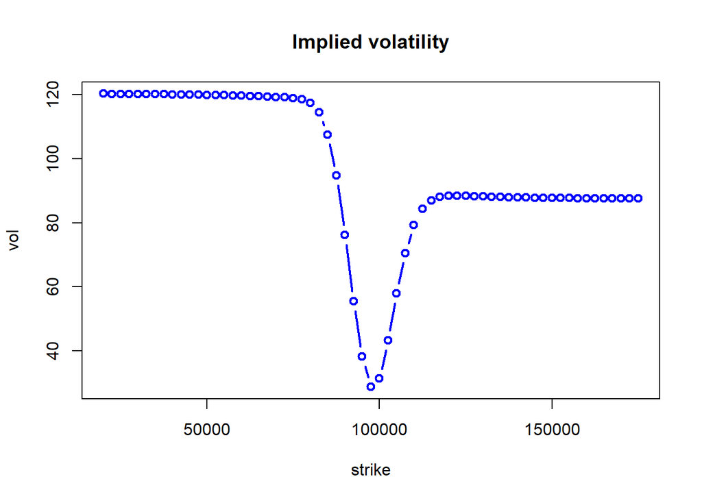

```r
plot(strike,vol,col = 'blue',type = 'b',pch = 21,main = 'Implied volatility',lwd = 2)
```

https://www.moex.com/ru/derivatives/optionsdesk.aspx?code=RTS-12.22

При выводе уравнения Блэка -Шольца ничего не говорилось про зависимость волатильности от страйка, более того предполагается ее постоянство. На графике мы наблюдаем то, что получило название улыбка волатильности или volatility smile. Это слабое место теории Блэка-Шольца преодолено многими другими моделями ценообразования опционов, которые появилияь позднее. Вот некоторые из них:

- Модель Хестона https://en.wikipedia.org/wiki/Heston_model
- Модель SABR https://en.wikipedia.org/wiki/SABR_volatility_model
- Модели предполагающие, что случайный процесс динамики базового актива отличен от Винеровского или процесса Ито, а например Variance Gamma процесс https://en.wikipedia.org/wiki/Variance_gamma_process

Некоторые модели ценообразования опционов в R реализованы, нет в R опционов по Variance Gammа модели, ее пришлось сделать самостоятельно.

Например, в следующем shiny реализовано оценивание опционов на бонды и построение улыбки волатильности по модели Хестона. http://shiny.ilykei.com/ANDoynikov/Options/Heston_10Year_T_Note/

А здесь реализовано вычисление опциона по модели Variance-Gamma https://shiny.ilykei.com/ANDoynikov/Options/vg-option/

Метод для вычисления подразумеваемой волатильности по модели Блэка-Шольца в R это GBSVolatility()

```r
S <- 100
T <- 0.25
sigma <- 0.2
r <- 0.01
b <- 0
X <- 110
TypeFlag <- "c"
call <- GBSOption(TypeFlag, S = S, X = X, Time = T, r = r, b = b, sigma = sigma)
call@price
```

```
## [1] 0.9515615
```

Посчитали цену опциона при волатильности $\sigma= 0.2$. Теперь посчитаем какая волатильность соотвеетсвует этой цене.

```r
impvol <- GBSVolatility(call@price, TypeFlag, S, X, Time = T, r, b, tol=0.0001, maxiter = 100)
impvol
```

```
## [1] 0.2000168
```

## Портфели опционов

В зависимости от прогноза дальнейшего развития рынка можно сформировать свой портфель опционов, который при удачном развитии рынка принесет инвестору прибыль. Разные портфели, прибыль и убытки по ним поможет посмотреть следующее приложение.

https://shiny.ilykei.com/ANDoynikov/myOptionViewer/

### Как пользоваться приложением

На верхнем графике отображается:

- Выплаты по опциону, если ждать времени его окончания, с учетом денег заплаченнных при покупке или полученных при продаже (синий цвет)
- Стоимость опциона в момент заключения контракта в зависимости от страйка (зеленый цвет)

На нижнем графике отображается:

- Выплаты по портфелю, если ждать времени его окончания, с учетом денег заплаченнных при покупке или полученных при продаже (синий цвет)
- Итоговая прибыль или убытки от портфеля, если портфель закрыть в некоторый момент времени до окончания опционов портфеля (красная точка)

Кнопки:

- Кнопка *Add Option* добавляет опцион из верхнего графика в портфель
- Кнопка *Buy Stock* покупка 1 акции и добавление ее в портфель
- Кнопка *Sell Stock* короткая продажа 1 акции и добавление ее в портфель
- Кнопка *New portfolio* обнуляет портфель. После чего можно собирать новый.

После того как портфель сформирован меняйте *maturity* , *underlying* и *volatility*, чтобы посмотреть прибыль и убытки портфеля в зависимости от рынка (красная точка).